# Caret Functionality

## Plotting Predictors

### Example;predicting wages using the Wage data.

```r
library(ISLR)
library(ggplot2)
library(lattice)
library(caret)
data(Wage)
dim(Wage)
```

```
## [1] 3000   11
```

```r
str(Wage)
```

```
## 'data.frame':    3000 obs. of  11 variables:
##  $ year      : int  2006 2004 2003 2003 2005 2008 2009 2008 2006 2004 ...
##  $ age       : int  18 24 45 43 50 54 44 30 41 52 ...
##  $ maritl    : Factor w/ 5 levels "1. Never Married",..: 1 1 2 2 4 2 2 1 1 2 ...
##  $ race      : Factor w/ 4 levels "1. White","2. Black",..: 1 1 1 3 1 1 4 3 2 1 ...
##  $ education : Factor w/ 5 levels "1. < HS Grad",..: 1 4 3 4 2 4 3 3 3 2 ...
##  $ region    : Factor w/ 9 levels "1. New England",..: 2 2 2 2 2 2 2 2 2 2 ...
##  $ jobclass  : Factor w/ 2 levels "1. Industrial",..: 1 2 1 2 2 2 1 2 2 2 ...
##  $ health    : Factor w/ 2 levels "1. <=Good","2. >=Very Good": 1 2 1 2 1 2 2 1 2 2 ...
##  $ health_ins: Factor w/ 2 levels "1. Yes","2. No": 2 2 1 1 1 1 1 1 1 1 ...
##  $ logwage   : num  4.32 4.26 4.88 5.04 4.32 ...
##  $ wage      : num  75 70.5 131 154.7 75 ...
```

```r
summary(Wage)
```

```
##       year           age                     maritl           race
##  Min.   :2003   Min.   :18.00   1. Never Married: 648   1. White:2480
##  1st Qu.:2004   1st Qu.:33.75   2. Married      :2074   2. Black: 293
##  Median :2006   Median :42.00   3. Widowed      :  19   3. Asian: 190
##  Mean   :2006   Mean   :42.41   4. Divorced     : 204   4. Other:  37
##  3rd Qu.:2008   3rd Qu.:51.00   5. Separated    :  55
##  Max.   :2009   Max.   :80.00
##
##               education                     region
##  1. < HS Grad      :268   2. Middle Atlantic   :3000
##  2. HS Grad        :971   1. New England       :   0
##  3. Some College   :650   3. East North Central:   0
##  4. College Grad   :685   4. West North Central:   0
##  5. Advanced Degree:426   5. South Atlantic    :   0
##                           6. East South Central:   0
##                           (Other)              :   0
##            jobclass               health      health_ins      logwage
##  1. Industrial :1544   1. <=Good     : 858   1. Yes:2083   Min.   :3.000
##  2. Information:1456   2. >=Very Good:2142   2. No : 917   1st Qu.:4.447
##                                                            Median :4.653
##                                                            Mean   :4.654
##                                                            3rd Qu.:4.857
##                                                            Max.   :5.763
##
##       wage
##  Min.   : 20.09
##  1st Qu.: 85.38
##  Median :104.92
##  Mean   :111.70
##  3rd Qu.:128.68
##  Max.   :318.34
##
```

```r
table(Wage$race)
```

```
##
## 1. White 2. Black 3. Asian 4. Other
##     2480      293      190       37
```

```r
table(Wage$education)
```

```
##
##       1. < HS Grad         2. HS Grad    3. Some College
##                268                971                650
##    4. College Grad 5. Advanced Degree
##                685                426
```

```r
table(Wage$jobclass)
```

```
##
##  1. Industrial 2. Information
##           1544           1456
```

```r
table(Wage$region)
```

```
##
##        1. New England    2. Middle Atlantic 3. East North Central
##                     0                  3000                     0
## 4. West North Central     5. South Atlantic 6. East South Central
##                     0                     0                     0
## 7. West South Central           8. Mountain            9. Pacific
##                     0                     0                     0
```

```r
table(Wage$health)
```

```
##
##      1. <=Good 2. >=Very Good
##            858           2142
```

```r
#Get training/test sets
inTrain <-createDataPartition(y=Wage$wage,p=0.70,list=FALSE)
training <-Wage[inTrain,]
testing <-Wage[-inTrain,]
dim(training)
```

```
## [1] 2102   11
```

```r
dim(testing)
```

```
## [1] 898  11
```

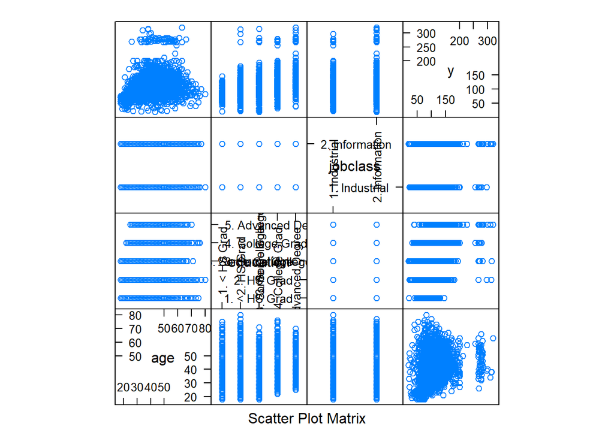

```r
#feature plot (caret package)
featurePlot(x=training[,c("age","education","jobclass")],y=training$wage,plot="pairs")
```

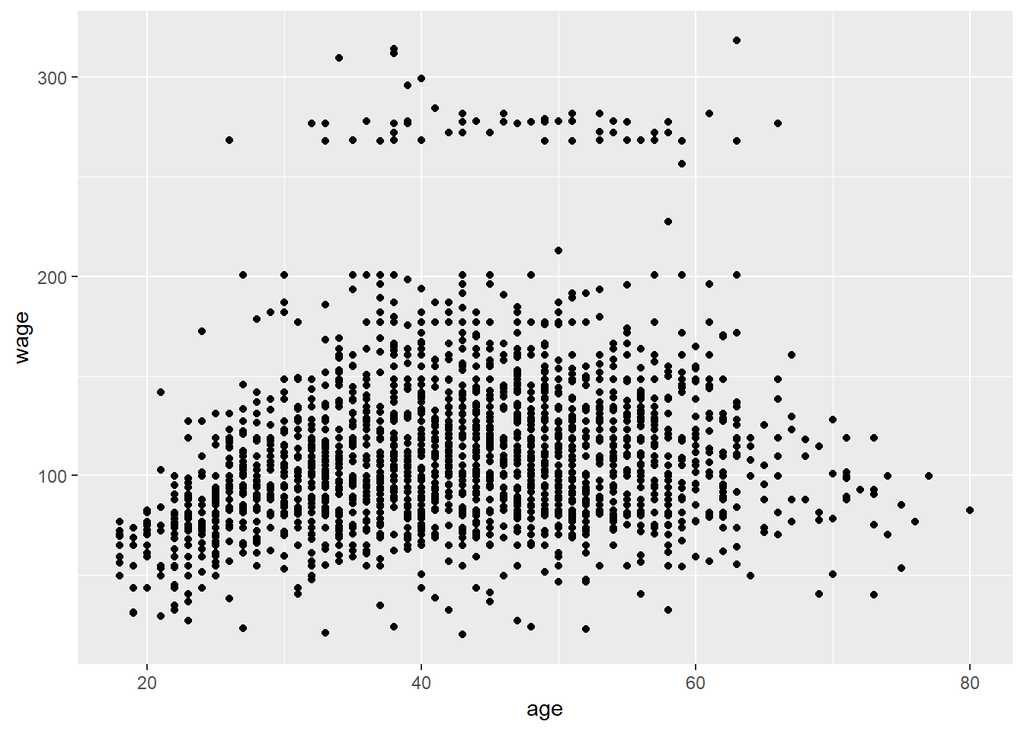

```r
#Qplot(ggplot2 package)
qplot(age,wage,data=training)
```

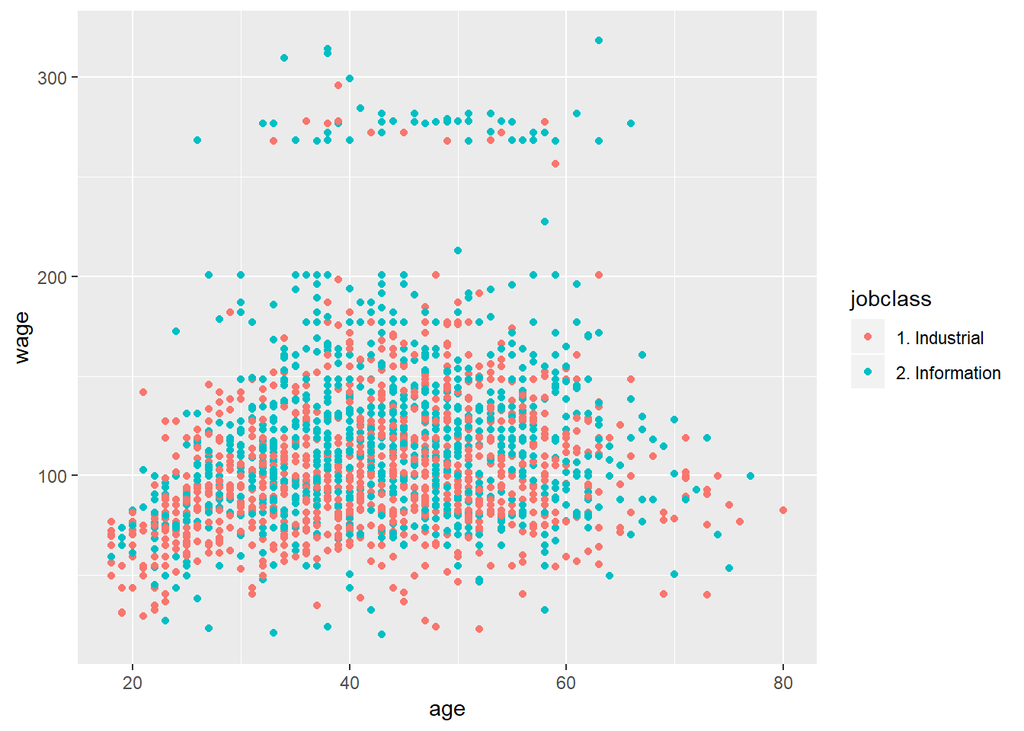

```r
#Qplot with color
qplot(age,wage,color=jobclass,data=training)
```

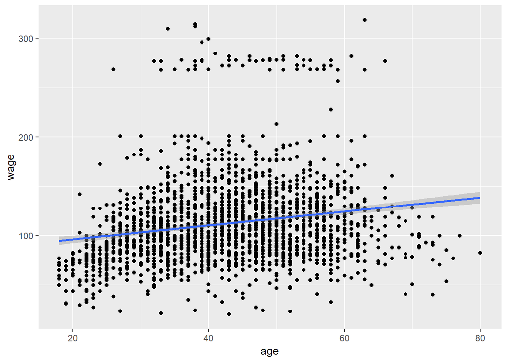

```r
#Add regression smoothers(ggplot2 package)
qplot(age,wage,data=training)+geom_smooth(method="lm",formula=y~x)
```

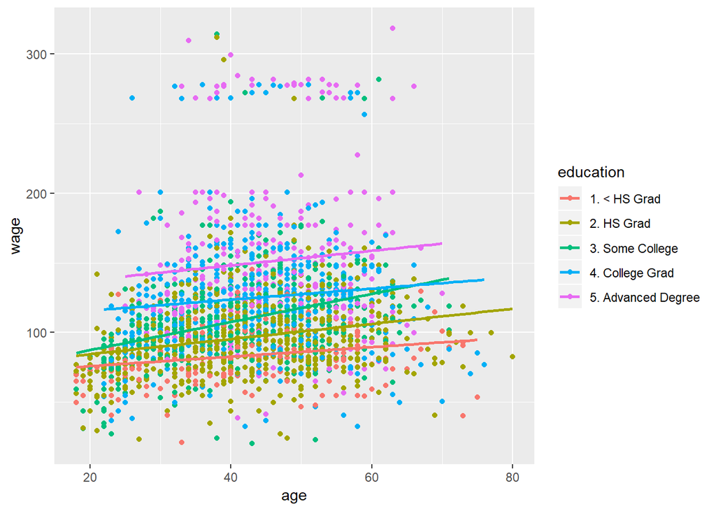

```r
qplot(age,wage,color=education,data=training)+geom_smooth(method="lm",se=FALSE)
```

## cut2,making factors (Hmisc package)

```r
library(ISLR)
library(ggplot2)
library(lattice)
library(caret)
data(Wage)
inTrain <-createDataPartition(y=Wage$wage,p=0.70,list=FALSE)
training <-Wage[inTrain,]
testing <-Wage[-inTrain,]
library(Hmisc)
library(gridExtra)
cutWage <-cut2(training$wage,g=3)
table(cutWage)
```

```
## cutWage
## [ 20.1, 92) [ 92.0,119) [118.9,318]
##         706         728         668
```

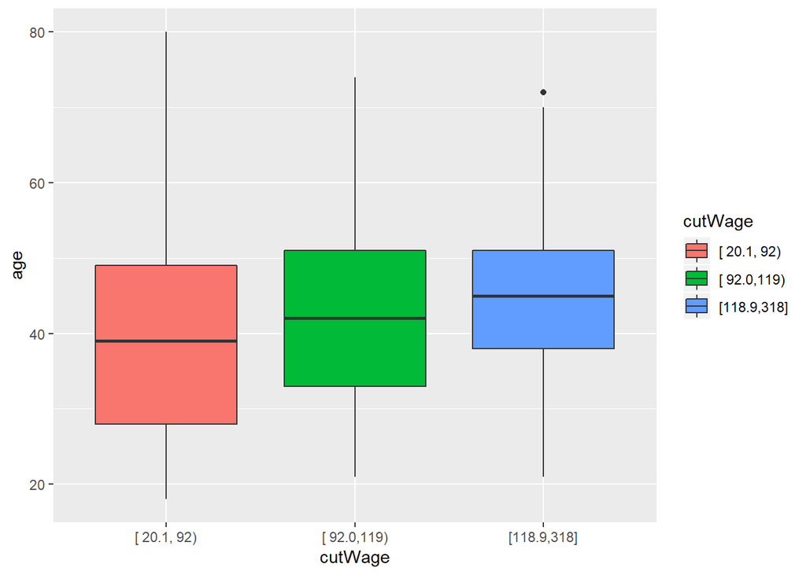

```r
#Boxplots with cut2
p1 <-qplot(cutWage,age,data=training,fill=cutWage,geom=c("boxplot"))
p1
```

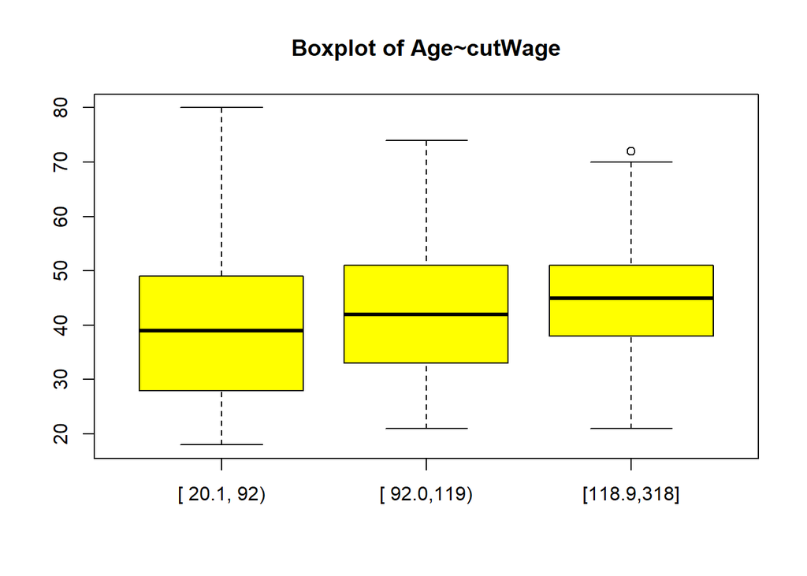

```r
#Base boxplot
boxplot(age~cutWage,data=training,col="yellow",main="Boxplot of Age~cutWage")
```

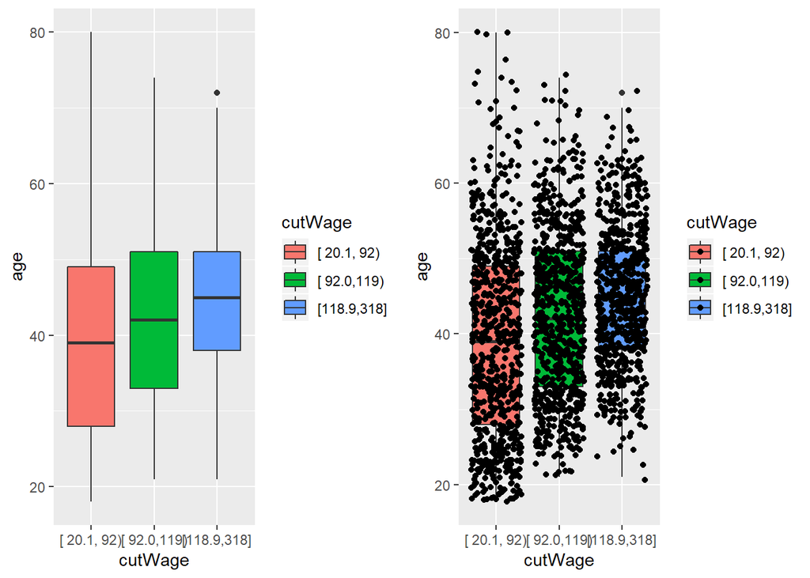

```r
#Boxplots with points overlayed
p2 <-qplot(cutWage,age,data=training,fill=cutWage,geom=c("boxplot","jitter"))
grid.arrange(p1,p2,ncol=2)
```

```r
#Tables
t1 <-table(cutWage,training$jobclass)
t1
```

```
##
## cutWage       1. Industrial 2. Information
##   [ 20.1, 92)           437            269
##   [ 92.0,119)           364            364
##   [118.9,318]           259            409
```

```r
prop.table(t1,1) #proportion
```

```
##
## cutWage       1. Industrial 2. Information
##   [ 20.1, 92)     0.6189802      0.3810198
##   [ 92.0,119)     0.5000000      0.5000000
##   [118.9,318]     0.3877246      0.6122754
```

## Density plots

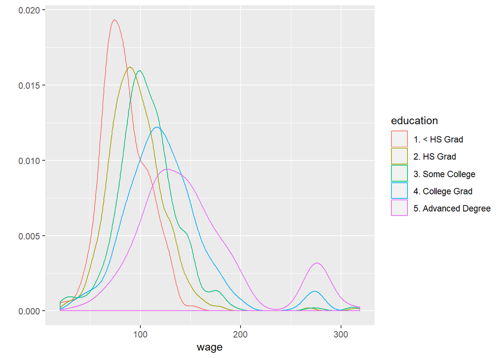

```r
library(ggplot2)
library(lattice)
library(caret)
data(Wage)
qplot(wage,color=education,data=training,geom="density")
```

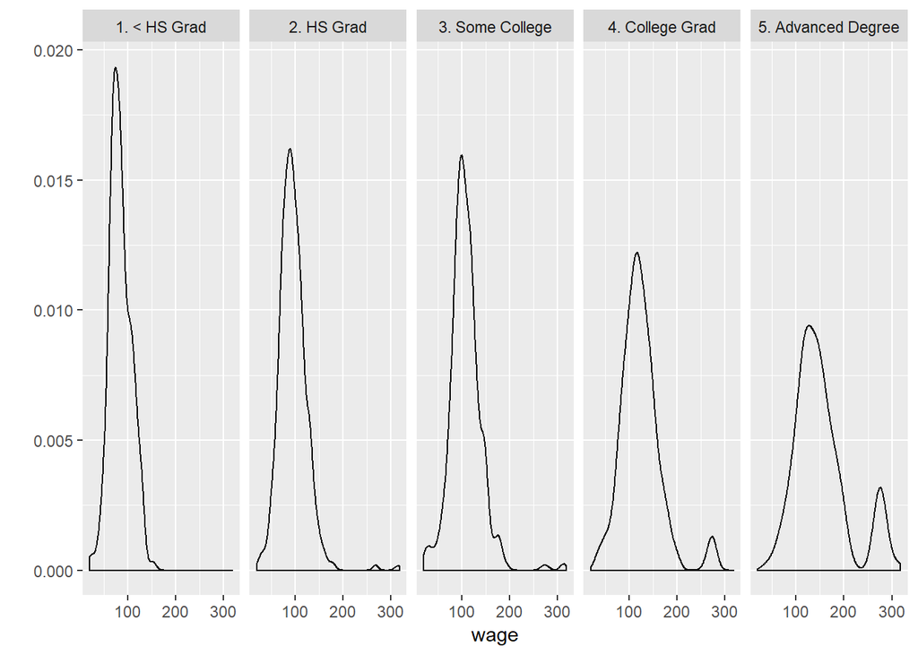

```r
qplot(wage,data=training,geom="density",facets=.~education)
```

## Basic Preprocessing

- Preprocessing can be more useful when using model based approaches than when you are using more nonparametric approaches. We preprocess predictor variables.

### Why Preprocess

- we preprocess to transform data so that the machine learning algorithms don’t get tricked by the fact that it’s skewed and highly variable.
- One way that you can do this is by basically standardizing variables i.e. take the variable values, subtract their mean and divide that whole quantity by the standard deviation. When you do this, the mean of the variable that you have will be zero (0) and the standard deviation will be one (1). So this will reduce a lot of the variability in the data and it will standardize the variable somewhat.
- When we apply a prediction algorithm to the test set. We can only use parameters that we estimated in the training set. In other words, when we apply this same standardization to the test set, we have to use the mean and standard deviation from the training set to standardize the testing set values. This means that when you do the standardizaiton the mean will not be exactly zero (0) in the test set and the standard deviation will not be exactly one (1), because we standardized by parameters estimated in the training set byt hopefully they will be close to those values. You can also use the preProcess function to do a lot of standardization. The preProcess function is built into the caret package.

### Why preProcess?continued

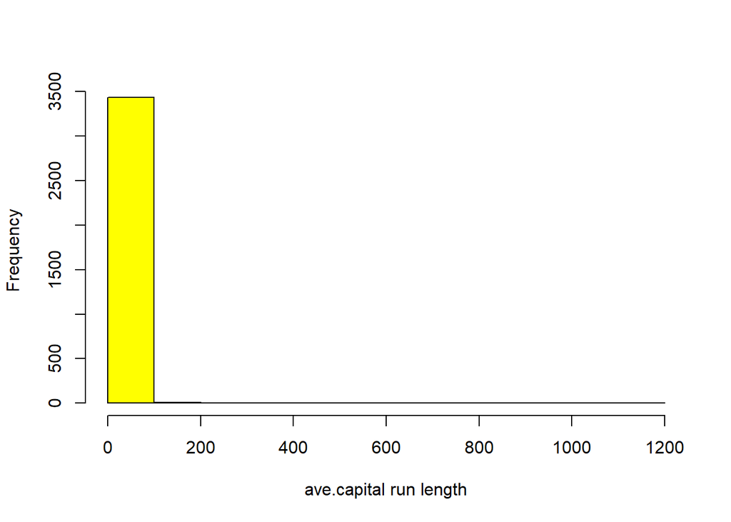

```r
library(ggplot2)
library(lattice)
library(caret)
library(kernlab)
data(spam)
inTrain <-createDataPartition(y=spam$type,p=0.75,list=FALSE)
training <-spam[inTrain,]
testing <-spam[-inTrain,]
hist(training$capitalAve,main="",xlab="ave.capital run length",col="yellow")
```

```r
#The capitalAve variable is very skewed so we have to preProcess
mean(training$capitalAve)
```

```
## [1] 5.609742
```

```r
sd(training$capitalAve) # This is very large so it is much much variable. We have to standardize.
```

```
## [1] 35.99257
```

```r
trainCapAve <-training$capitalAve
trainCapAves <-(trainCapAve-mean(trainCapAve))/sd(trainCapAve)
mean(trainCapAves)
```

```
## [1] -8.819718e-18
```

```r
sd(trainCapAves)
```

```
## [1] 1
```

```r
#We standardized to reduce the variability
#Apply on the test set
testCapAve <-testing$capitalAve
testCapAves <-(testCapAve-mean(testCapAve))/sd(testCapAve)
mean(testCapAves)
```

```
## [1] 1.914076e-17
```

```r
sd(testCapAves)
```

```
## [1] 1
```

## Use preProcess function to standardize

```r
library(ggplot2)
library(lattice)
library(caret)
library(kernlab)
data(spam)
preObj <-preProcess(training[,-58],method=c("center","scale"))
trainCapAves <-predict(preObj,training[,-58])$capitalAve
mean(trainCapAves)
```

```
## [1] -8.819718e-18
```

```r
sd(trainCapAves)
```

```
## [1] 1
```

```r
#You can use the preProcessing object to apply the test set.
testCapAves <-predict(preObj,testing[,-58])$capitalAve
mean(testCapAves)
```

```
## [1] -0.04648937
```

```r
sd(testCapAves)
```

```
## [1] 0.3271592
```

```r
#Fit the model
set.seed(32343)
modelFit <-train(type~.,data=training,preProcess=c("center","scale"),method="glm")
modelFit
```

```
## Generalized Linear Model
##
## 3451 samples
##   57 predictor
##    2 classes: 'nonspam', 'spam'
##
## Pre-processing: centered (57), scaled (57)
## Resampling: Bootstrapped (25 reps)
## Summary of sample sizes: 3451, 3451, 3451, 3451, 3451, 3451, ...
## Resampling results:
##
##   Accuracy   Kappa
##   0.9171051  0.8249406
```

```r
modelFit$finalModel
```

```
##
## Call:  NULL
##
## Coefficients:
##       (Intercept)               make            address
##         -11.24509           -0.09015           -0.19116
##               all              num3d                our
##           0.02765            4.18259            0.43037
##              over             remove           internet
##           0.16943            0.78751            0.24857
##             order               mail            receive
##           0.09723            0.05825           -0.02425
##              will             people             report
##          -0.13421           -0.00409            0.03831
##         addresses               free           business
##           0.23376            0.87348            0.41103
##             email                you             credit
##           0.08271            0.15689            0.36910
##              your               font             num000
##           0.23520            0.12219            0.70979
##             money                 hp                hpl
##           0.37406           -3.37533           -0.90419
##            george             num650                lab
##         -32.28247            0.25877           -1.21735
##              labs             telnet             num857
##          -0.13145           -1.89479            0.69479
##              data             num415              num85
##          -0.35124            0.38245           -1.22127
##        technology            num1999              parts
##           0.46461            0.03090           -0.12464
##                pm             direct                 cs
##          -0.32974            0.35913          -19.66661
##           meeting           original            project
##          -2.68319           -0.42232           -1.18776
##                re                edu              table
##          -0.87769           -1.33603           -0.35663
##        conference      charSemicolon   charRoundbracket
##          -1.39190           -0.31845           -0.04575
## charSquarebracket    charExclamation         charDollar
##          -0.14118            0.25756            1.25417
##          charHash         capitalAve        capitalLong
##           1.50283            0.31428            1.51474
##      capitalTotal
##           0.85046
##
## Degrees of Freedom: 3450 Total (i.e. Null);  3393 Residual
## Null Deviance:       4628
## Residual Deviance: 1363  AIC: 1479
```